# 2 Week Assignment DATA607

Christian Thieme

2/6/2020

## Assignment Week 2 DATA607: SQL and R

### Purpose:

The purpose of this assignment is three-fold:

1. To demonstrate the proper creation and population of a SQL database/tables in a MySQL database.
2. To show how to access data from SQL directly using R
3. To demonstrate several methods for dealing with null values in data

Let’s first start by importing the libraries we’ll need:

```r
library(RMySQL)
library(tidyverse)
library(ggplot2)
library(gridExtra)
```

Now, using R, let’s pull the data from the tables we’ve created into a single data frame and have a look at the first couple rows:

```r
con <- dbConnect(RMySQL::MySQL(),
          host = "localhost",
          port = 3306,
          dbname = "movie_ratings",
          user = "root",
          password = "mysql")

q <- dbSendQuery(con, "SELECT
r.rating_id,
m.movie_name,
m.release_year,
f.friend_first_name,
f.friend_last_name,
r.rating
FROM movie_ratings.ratings r
LEFT JOIN movie_ratings.movies m ON r.id_movie = m.movie_id
LEFT JOIN movie_ratings.friends f ON r.id_friend = f.friend_id")

mvr <- fetch(q, n=-1)
head(mvr)
```

```
##   rating_id                                    movie_name release_year
## 1         1 Star Wars: Episode IX - The Rise of Skywalker         2019
## 2         2                                 The Lion King         2019
## 3         3                                    Just Mercy         2019
## 4         4                       Jumanji: The Next Level         2019
## 5         5                             Avengers: Endgame         2019
## 6         6                                     Frozen II         2019
##   friend_first_name friend_last_name rating
## 1              Abby             Fife      5
## 2              Abby             Fife      3
## 3              Abby             Fife      5
## 4              Abby             Fife      4
## 5              Abby             Fife      4
## 6              Abby             Fife      5
```

Let’s also get a feel for the dimensionality of this data:

```r
dim(mvr)
```

```
## [1] 35  6
```

One of the first things we want to do is understand if we have nulls within our data. We can look at that with the below code:

```r
colSums(is.na(mvr))
```

```
##         rating_id        movie_name      release_year friend_first_name
##                 0                 0                 0                 0
##  friend_last_name            rating
##                 0                 7
```

Based on the above, it looks like there are 7 rows in the rating column that don’t have values. Let’s get a look at these rows and see what they are:

```r
nas <- mvr %>% filter(is.na(rating))
nas
```

```
##   rating_id                                    movie_name release_year
## 1         9                                 The Lion King         2019
## 2        14                                    Gemini Man         2019
## 3        16                                 The Lion King         2019
## 4        17                                    Just Mercy         2019
## 5        22 Star Wars: Episode IX - The Rise of Skywalker         2019
## 6        28                                    Gemini Man         2019
## 7        35                                    Gemini Man         2019
##   friend_first_name friend_last_name rating
## 1             Janis      Bartholomew     NA
## 2             Janis      Bartholomew     NA
## 3            Thomas             Fife     NA
## 4            Thomas             Fife     NA
## 5          Savannah           Dotson     NA
## 6          Savannah           Dotson     NA
## 7             Royce      Bartholomew     NA
```

Based on the rows above that contain nulls, it looks like these are columns where a person did not respond to the survey. In our analysis, it probably makes sense to drop these rows entirely, because the person has not seen the movie, meaning there really should not be a rating or even a row for that movie associated with that person. We have a couple options, we can drop the rows entirely, tell R to ignore the nulls, or we can impute a value for the missing value. Let’s first show how we can exclude nulls from our calculations before we drop the rows entirely or impute values. To show this, let’s calculate an average rating per movie.

```r
avg_excl_nulls <- mvr %>% group_by(movie_name) %>% summarize(avg_rating = mean(rating, na.rm = TRUE)) %>% arrange(desc(avg_rating))
avg_excl_nulls
```

```
## # A tibble: 7 x 2
##   movie_name                                    avg_rating
##   <chr>                                              <dbl>
## 1 Just Mercy                                          4.5
## 2 Star Wars: Episode IX - The Rise of Skywalker       4.5
## 3 Avengers: Endgame                                   4.4
## 4 Frozen II                                           4.4
## 5 Jumanji: The Next Level                             4
## 6 The Lion King                                       2.67
## 7 Gemini Man                                          2
```

The above is what we would consider the true average ratings for each movie. We were able to calculate this value by telling R to remove the nulls from the calculation with the “na.rm = True” argument in our code. Let’s now take a look at imputing a value for our missing values and see how that affects the overall average. There are a couple ways we could do this, we could use the median rating of the movie as our imputed value for each movie, or we could use the median rating of each user to impute our missing values. We use the median here as opposed to the average so as not be be skewed by outliers. In this case, it probably makes more sense to impute our value off of the median rating of the movie. Let’s move forward with that approach:

```r
jm <- mvr %>% filter(movie_name == "Just Mercy") %>% summarize(median(rating, na.rm = TRUE))
sw <- mvr %>% filter(movie_name == "Star Wars: Episode IX - The Rise of Skywalker") %>% summarize(median(rating, na.rm = TRUE))
tlk <- mvr %>% filter(movie_name == "The Lion King") %>% summarize(median(rating, na.rm = TRUE))
gm <- mvr %>% filter(movie_name == "Gemini Man") %>% summarize(median(rating, na.rm = TRUE))


imputed <- mvr %>% mutate(rating = replace(rating, movie_name == "Just Mercy" & is.na(rating) == TRUE, jm[1,1])) %>%
  mutate(rating = replace(rating, movie_name == "Star Wars: Episode IX - The Rise of Skywalker" & is.na(rating) == TRUE, sw[1,1])) %>%
  mutate(rating = replace(rating, movie_name == "The Lion King" & is.na(rating) == TRUE, tlk[1,1])) %>%
  mutate(rating = replace(rating, movie_name == "Gemini Man" & is.na(rating) == TRUE, gm[1,1]))

colSums(is.na(imputed))
```

```
##         rating_id        movie_name      release_year friend_first_name
##                 0                 0                 0                 0
##  friend_last_name            rating
##                 0                 0
```

Looking at the above, it looks like we were able to successfully impute and fill the null values with the median rating for each movie.

Let’s now take a look at how our imputations affected the averages:

```r
imputed_avg <- imputed %>% group_by(movie_name) %>% summarize(avg = mean(rating, na.rm = TRUE)) %>% arrange(desc(avg))
imputed_avg
```

```
## # A tibble: 7 x 2
##   movie_name                                      avg
##   <chr>                                         <dbl>
## 1 Just Mercy                                      4.5
## 2 Star Wars: Episode IX - The Rise of Skywalker   4.5
## 3 Avengers: Endgame                               4.4
## 4 Frozen II                                       4.4
## 5 Jumanji: The Next Level                         4
## 6 The Lion King                                   2.8
## 7 Gemini Man                                      2
```

Just in eyeballing these, it looks like using the median to impute our values only changed the averages very slightly for a couple of the movies. To get a better feel for this, let’s graph these values next to each other and see how they compare:

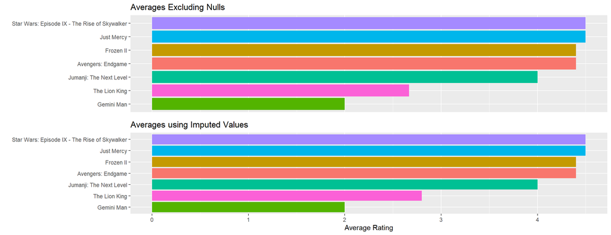

```r
avg_non_impute <- ggplot(data = avg_excl_nulls) +
  aes(x = reorder(movie_name, avg_rating), y = avg_rating, fill = movie_name) +
  geom_bar(stat = "identity") +
  coord_flip() +
  labs(title = "Averages Excluding Nulls") +
  xlab(" ") +
  ylab(" ") +
  theme(axis.title.x=element_blank(),
        axis.text.x=element_blank(),
        axis.ticks.x=element_blank()) +
  theme(legend.position='none')

avg_impute <- ggplot(data = imputed_avg) +
  aes(x = reorder(movie_name, avg), y = avg, fill = movie_name) +
  geom_bar(stat = "identity") +
  labs(title = "Averages using Imputed Values") +
  coord_flip() +
  xlab(" ") +
  ylab("Average Rating") +
  theme(legend.position='none')


gridExtra::grid.arrange(avg_non_impute, avg_impute, ncol = 1)
```

As you can tell, adding the imputed values didn’t really change the averages much. That in part, is because our population is so small and the number of values to be imputed was fairly small as well.

Now, let’s take a look at the last method to get rid of nulls. Instead of doing the above, we could have just dropped the rows that contained nulls. Based on our dataset, this is probably a good option since nulls actually mean that a person didn’t rate a movie. Depending on your dataset and the values that are missing, this can be a good idea, but you need to really understand the risks of what you are losing when you remove rows with null values. In our case, we aren’t losing other measurements, we are in fact basically just removing blank rows since these rows represent blank/empty ratings. Let’s go ahead and drop the nulls from our original data frame and then check for nulls:

```r
mvr <- mvr %>% drop_na()

colSums(is.na(mvr))
```

```
##         rating_id        movie_name      release_year friend_first_name
##                 0                 0                 0                 0
##  friend_last_name            rating
##                 0                 0
```

Looking at the above, it looks like we were able to successfully remove all the null values from our data set.

Having removed the null values, and looking at the average rating of each movie above, let’s now take a look at the distribution of values within these ratings for each movie:

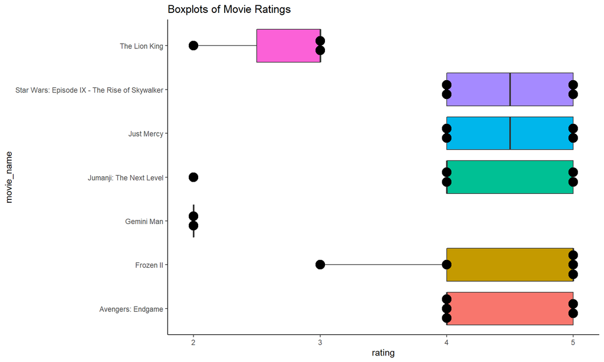

```r
theme_set(theme_classic())

ggplot(data = mvr) +
  aes(x = movie_name, y = rating, fill = movie_name) +
  geom_boxplot() +
  geom_dotplot(binaxis='y',
               stackdir='center',
               dotsize = .75,
               fill="black") +
  coord_flip() +
  labs(title = "Boxplots of Movie Ratings") +
  theme(legend.position='none')
```

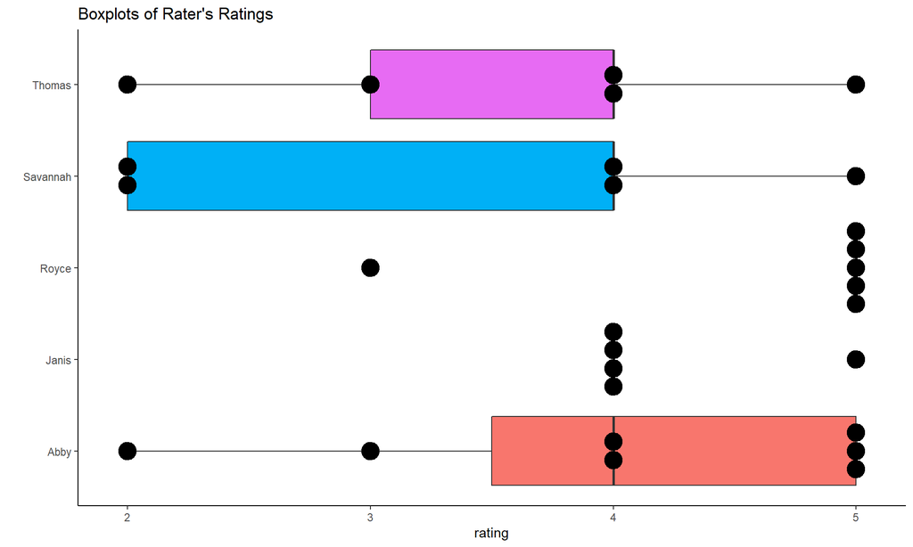

```r
theme_set(theme_classic())

ggplot(data = mvr) +
  aes(x = friend_first_name, y = rating, fill = friend_first_name) +
  geom_boxplot() +
  geom_dotplot(binaxis='y',
               stackdir='center',
               dotsize = .75,
               fill="black") +
  coord_flip() +
  labs(title = "Boxplots of Rater's Ratings") +
  theme(legend.position='none') +
  xlab(" ")
```

In looking at the chart above, it does appear that both Janis and Royce tend to have higher ratings overall than the other three raters.

How do our averages compare overall to the general public? In reviewing several movie rating agencies, it appears that the averages we computed here fall closely in line with what the general public thought about each movie. To extend this analysis, we could gather this data from each rating agency and add it to our movie_rating schema and use it to compare against what we have shown above.